# Earthquake risk index by neighborhood

Philippe Marchand

2026-02-03

This document aims to summarize the FEMA national risk index (NRI) for earthquakes by San Francisco analysis neighborhood. An exploratory analysis of the data at the census tract level was already done here.

## Load risk index and neighborhood datasets

The FEMA NRI data is the same as before, extracted for each census tract in San Francisco, but we remove three census tracts with fewer than 1000 residents; these correspond to Golden Gate Park, Lincoln Park and McLaren Park.

```r
library(tidyverse)
library(sf)
library(tidycensus)
library(ggrepel)
library(mapview)

nri <- read_sf("NRI_Shapefile_CensusTracts") %>%
    filter(COUNTY == "San Francisco", POPULATION > 1000) %>%
    select(matches("^(TRACT|POP|ERQK|SOVI|RESL|CRF)"))
```

The file matching each census tract to one of 42 analysis neighborhoods was downloaded from DataSF ([link](https://data.sfgov.org/Geographic-Locations-and-Boundaries/Analysis-Neighborhoods-2020-census-tracts-assigned/sevw-6tgi)).

```r
neigh <- read_csv("Analysis_Neighborhoods_-_2020_census_tracts_assigned_to_neighborhoods_20251118.csv")
neigh <- st_drop_geometry(neigh) %>%
    select(TRACT = tractce, neighborhood = neighborhoods_analysis_boundaries)
head(neigh)
```

```
## # A tibble: 6 × 2
##   TRACT  neighborhood
##   <chr>  <chr>
## 1 980900 Bayview Hunters Point
## 2 980600 Bayview Hunters Point
## 3 980501 McLaren Park
## 4 980401 The Farallones
## 5 061200 Bayview Hunters Point
## 6 061102 Chinatown
```

## Get additional census data

For now, the only additional variable considered is the percentage of renter vs. owner-occupied households. This is obtained from the 5-year American Community Survey (ACS) estimates. Variables *B25003_002* and *B25003_003* represent the count of owner-occupied households and renter-occupied households, respectively.

```r
own_rent <- get_acs(geography = "tract", state = "California",
                    county = "San Francisco", year = 2020,
                    variables = c("B25003_002", "B25003_003"))
```

The percentage of renters by census tract is calculated from those two counts.

```r
own_rent <- own_rent %>%
    mutate(TRACT = str_sub(GEOID, 6),
           variable = if_else(str_sub(variable, -1) == "2",
                              "own", "rent")) %>%
    select(TRACT, variable, estimate) %>%
    pivot_wider(names_from = variable, values_from = estimate) %>%
    mutate(rent_pct = rent / (rent + own) * 100)
head(own_rent)
```

```
## # A tibble: 6 × 4
##   TRACT    own  rent rent_pct
##   <chr>  <dbl> <dbl>    <dbl>
## 1 010101    75  1158     93.9
## 2 010102   110   799     87.9
## 3 010201   438   883     66.8
## 4 010202   397   667     62.7
## 5 010300   436  1715     79.7
## 6 010401   403   713     63.9
```

## Combine datasets and summarize by neighborhood

We join all datasets by census tract ID and select a few variables: population, percentage of renters and estimated loss ratio for buildings (estimated annual losses / total value of buildings), expressed as a percentage. See previous EDA for details on that variable.

```r
nri_neigh <- inner_join(nri, neigh) %>%
    inner_join(own_rent) %>%
    select(TRACT, neighborhood, POPULATION, RENT_PCT = rent_pct, ERQK_EALB, ERQK_EXPB) %>%
    mutate(EALB_PCT = ERQK_EALB / ERQK_EXPB * 100)
head(nri_neigh)
```

```
## Simple feature collection with 6 features and 7 fields
## Geometry type: MULTIPOLYGON
## Dimension:     XY
## Bounding box:  xmin: -13628470 ymin: 4550997 xmax: -13625550 ymax: 4552834
## Projected CRS: WGS 84 / Pseudo-Mercator
## # A tibble: 6 × 8
##   TRACT  neighborhood POPULATION RENT_PCT ERQK_EALB   ERQK_EXPB
##   <chr>  <chr>             <dbl>    <dbl>     <dbl>       <dbl>
## 1 010101 North Beach        2026     93.9  2871318. 2576585444.
## 2 010102 North Beach        2000     87.9   451781.  359573361.
## 3 010201 Russian Hill       2468     66.8  1411655.  833089749.
## 4 010202 Russian Hill       2074     62.7  1843880. 1400747237.
## 5 010300 Russian Hill       4062     79.7  2017779. 1151299084.
## 6 010401 North Beach        2214     63.9  1006745.  671061940.
## # ℹ 2 more variables: geometry <MULTIPOLYGON [m]>, EALB_PCT <dbl>
```

We can average the percentage of renters per neighborhood (weighted by population) and calculate a neighborhood-level building loss ratio:

```r
nri_neigh_sum <- nri_neigh %>%
    st_drop_geometry() %>%
    group_by(neighborhood) %>%
    summarize(TOTAL_POP = sum(POPULATION),
              RENT_PCT = weighted.mean(RENT_PCT, POPULATION),
              EALB_PCT = sum(ERQK_EALB) / sum(ERQK_EXPB) * 100)
```

Here is the neighborhood-level building loss ratio vs. the average percentage of renters. Each dot is scaled according to the population in the neighborhood.

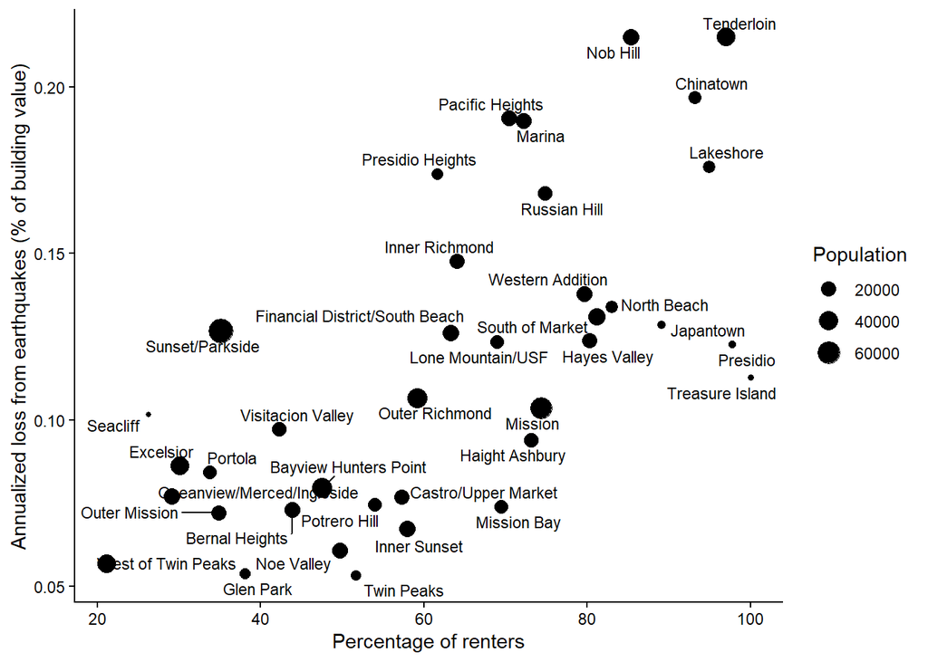

```r
ggplot(nri_neigh_sum, aes(x = RENT_PCT, y = EALB_PCT)) +
    geom_point(aes(size = TOTAL_POP)) +
    geom_text_repel(aes(label = neighborhood), size = 3,
                    max.overlaps = 20) +
    labs(x = "Percentage of renters",
         y = "Annualized loss from earthquakes (% of building value)",
         size = "Population") +
    theme_classic()
```

The neighborhoods with higher relative risk of building damage from earthquakes tend to also be renter-majority ones, and except for Lakeshore in the southwest, they are mostly located in the northeast of the city. Among the neighborhoods where most homes are owner-occupied, Sunset/Parkside stands out with a higher relative risk.